# Class 3: The Five Forces

MG106 Strategic Management

José Ignacio González Rojas

j.i.gonzalez-rojas@lse.ac.uk

London School of Economics and Political Science

June 25, 2026

## The Cola Wars reveal who captures the profit pool

### Five Forces explains why rivalry does not equal low profit

- Coke and Pepsi compete intensely
- Yet concentrate producers remain highly profitable

The paradox is high profit in a simple product category

How does the industry structure shapes the profit pool, and who captures it?

How can firms selling **simple beverage products** remain highly profitable for decades?

## Four questions structure today’s Five Forces investigation

### Use the framework to connect case evidence to profit capture

#### The four questions

1. Why are concentrate producers so profitable?
2. How do they control bottlers without owning every asset?
3. Did Coke-Pepsi rivalry destroy or create value?
4. How might health and category changes affect the industry?

Which force changes the economics, and for whom?

## Industry analysis separates profit pools from firm choices

### The evidence says industry structure matters, but does not explain everything

#### Industry effects

- Some profit differences come from the industry itself
- Forces shape the size and stability of the profit pool

#### Firm choices

- Firms still differ within the same industry
- Positioning and activity choices explain why C04 moves to Airborne

Use Five Forces to explain the profit pool, then ask who captures it.

**Discussion time**

*What forces explain the profitability?*

# Concentrate producers captured more value than bottlers

## The same beverage system created very different economics

|  | **Concentrate Producer** | **Bottler** |
| --- | --- | --- |
| **Gross Margin** | 83% | 35% |
| **Pretax Profit** | 35% | 9% |
| **Capital Required** | $50M | $75M+ per plant |
| **Plants Needed** | 1 nationally | 80-85 nationally |

Where is the bottleneck, and who avoids it?

## Entry barriers protected the concentrate profit pool

### Brand and channel barriers

- **Brand equity**: 100+ years of emotional connection
- **Shelf space**: Every slot occupied
- **Advertising efficiency**: incumbents spend more effectively

### System barriers

- **Global distribution**: costly to replicate
- **Exclusive territories**: Legal protection
- **Consumer identity**: “Pepsi Generation”

What would a new entrant need to replicate before selling one can?

## Supplier power was weak because inputs were ordinary

### The formula was proprietary, but most inputs were commodities

#### What goes in

- Caramel colouring
- Phosphoric acid
- Natural flavours
- Proprietary concentrate formula

#### Economics

- **Cost:** $0.12
- **Sells for:** $0.71
- **Margin:** 83%

Supplier power is limited

## Buyer power varied sharply by channel

### The same product met different buyers with different leverage

| **Channel** | **Power** | **Profit/Case** | **Why?** |
| --- | --- | --- | --- |
| Fountain | High | $0.09 | McDonald’s can switch |
| Supermarket | Medium | $0.23 | Some negotiation |
| Vending | Low | $0.97 | Captive consumers |

Which channel would you prioritise if you wanted margin rather than volume?

## Substitutes existed, but habits and brands muted the threat

### Free water did not eliminate paid cola consumption

| **Drink** | **Price** | **U.S. Consumption** |
| --- | --- | --- |
| Tap water | $0.00 | Available everywhere |
| Coke | **$1.00+** | **53 gallons/year** |

Strong brands and habits can limit substitution even when alternatives are available.

## Rivalry preserved value when it shifted away from concentrate price

### Competition can grow a category when it builds demand

#### Value-expanding rivalry

- Celebrity endorsements
- Package innovation
- Brand extensions
- Retail promotions

- Concentrate prices
- Sustained direct price wars
- Destabilising bottler relationships

Which rivalry choices expand demand, and which would destroy margin?

# Concentrate producers controlled bottling economics without owning every asset

## The value chain shows control without asset intensity

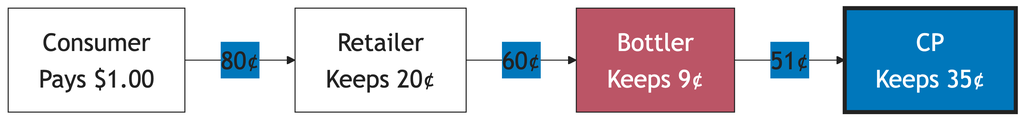

#### Evolution of control

Why might partial ownership be enough to steer the system?

# Rivalry expanded demand before maturity changed the game

## Competition did not destroy the profit pool

### Source-grounded evidence from the case

#### Rivalry expanded demand

- Coke and Pepsi both grew around 10% annually from 1975-1995
- Rivalry built consumption habits rather than only stealing share

#### Leaders consolidated share

- Coke and Pepsi held 76% of U.S. CSD volume in 2000
- Smaller rivals struggled to break the branded system

#### Maturity weakened the engine

- U.S. CSD growth slowed to 0.2% in 2000
- Profit depended more on pricing, channels, and adjacencies

#### Substitutes became more serious

- Non-carbs grew faster than CSDs in the late 1990s
- Growth options moved beyond cola

## Exhibit evidence shows why value-chain position mattered

### Concentrate producers and bottlers had different economics

#### Concentrate producer economics

- Very high gross margin per case
- Advertising and brand-building were major costs
- Low physical delivery burden
- Profit came from formula, brand, and bottler relationships

#### Bottler economics

- Much higher cost of sales and delivery burden
- Lower operating margin per case
- Channel execution and local logistics mattered
- Profit depended on volume, route density, and channel mix

The most attractive profit pool sat upstream.

## The winners were the firms that made rivalry category-building

### The strategic insight is not simply Coke versus Pepsi

#### What rivalry achieved

- Demand expanded strongly for two decades
- Coke and Pepsi reinforced cola as a habit and identity product
- The leaders consolidated a large share of U.S. CSD volume

#### What rivalry did not remove

- Bottlers still faced thin operating economics
- Some channels remained more powerful than others
- Maturity and substitutes made future growth less automatic

Rivalry can grow a category for a while, but category maturity changes the game.

# Health and category shifts threatened the old profit formula

## Changing conditions made the old model less automatic

### Demographic and health trends weakened the CSD growth engine

#### **Population shifts**

- Aging populations
- Declining fertility rates
- Changing youth preferences
- Health consciousness rising

#### **Market reality**

- **Volume growth:** 0.2% in 2000 (vs 5–7% in the 1980s)
- **Per capita:** Flat at 53 gallons
- **Non-carbs:** faster growth than CSDs
- Core cola demand under pressure

## New pressures widened the Five Forces lens

### Supply-chain and information pressures made the environment less forgiving

- **Aluminum prices**: Geopolitical tensions
- **Global logistics**: Rising costs
- **Water scarcity**: Future constraint
- **Sweetener volatility**: Climate impacts

### Information-age challenges

- **Instant health info**: Ingredient awareness
- **Sweetener concerns**: Even “zero” options questioned
- **Targeted activism**: Social media campaigns
- **Peer influence**: Health trends viral

## Strategic options trade off core protection against category renewal

### Option 1: Defend the core

#### Defend cola profits

- Harvest cash
- Accept decline
- Focus on loyalists

**Risk:** gradual decline

### Option 2: Diversify

#### Total beverage company

- Buy growth brands
- Leverage distribution
- New categories

**Risk:** Diluted focus

### Option 3: Innovate

#### Redefine the category

- Health-forward colas
- Functional benefits
- Sustainable packaging

**Risk:** Brand confusion

# Structure explains profit capture

## Concentrate producers captured more value because several forces aligned

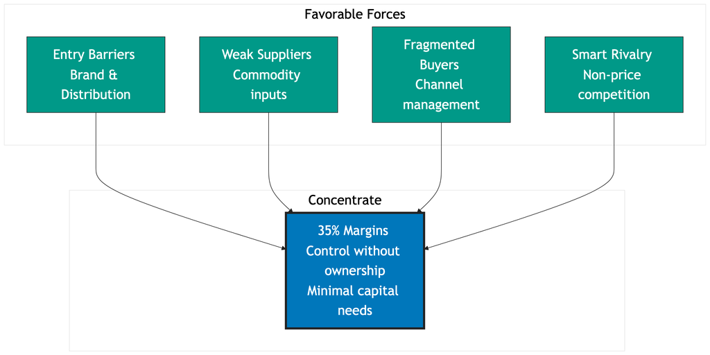

## Structure, control, and rivalry interact

### Structure drives profitability

Concentrate producers win through favorable forces while bottlers struggle

### Control beats ownership

Shape the value chain without owning the assets

### Rivalry can preserve value

Cola Wars coincided with growth, but maturity and substitutes changed the threat

### Conditions change

Health trends and information flows challenge the old model

Strong strategy links position, evidence, and profit implications.

## Read Airborne as an activity-system case

### Essential preparation for tomorrow

**READ: Airborne Express**

- What value proposition does Airborne offer?
- How does focus shape its activity system?
- Where are the trade-offs?